# Introduction to StatComp18049

zheng datang

2019-01-11

## The 1th Homework

Example1：Matrix computation

```r
X <- matrix(5:8, 2)
rownames(X) <- c("a", "b")
colnames(X) <- c("c", "d")
X
```

```
##   c d
## a 5 7
## b 6 8
```

```r
Y <- matrix(1:4, 2)
rownames(Y) <- c("e", "f")
colnames(Y) <- c("g", "h")
Y
```

```
##   g h
## e 1 3
## f 2 4
```

```r
cbind(X, Y)
```

```
##   c d g h
## a 5 7 1 3
## b 6 8 2 4
```

```r
rbind(X, Y)
```

```
##   c d
## a 5 7
## b 6 8
## e 1 3
## f 2 4
```

```r
t(X)
```

```
##   a b
## c 5 6
## d 7 8
```

Example2：R drawing, using function par to permanently change drawing parameters

```r
dose <- c(20, 30, 40, 45, 60)
drugA <- c(16, 20, 27, 40, 60)
drugB <- c(15, 18, 25, 31,40)

opar <- par(no.readonly = TRUE)
par(mfrow=c(1,2))
par(lwd=2, cex=1.5)
par(cex.axis=0.75, font.axis=3)
#plot(dose, drugA, type="b", pch=19, lty=2, col="red")
#plot(dose, drugA, type="b", pch=23, lty=6, col="blue", bg="green")
par(opar)
```

Example3：Write your own functions

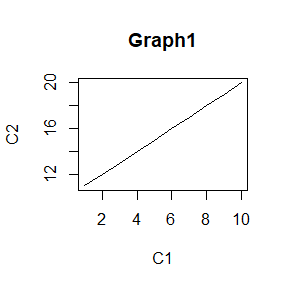

```r
myfun <- function(S,C1, C2) {
mfrow=c(1,1)
plot(C1, C2, type="l")
title(S)
}

c1<-c(1:10)
c2<-c(11:20)
s<-"Graph1"
myfun(s,c1,c2)
```

Summary: Three examples of completing “R for Beginners” 。

## The 2th Homework

## question3.5

Use the inverse transform method to generate a random sample of size 1000 from the distribution of X. Construct a relative frequency table and compare the empirical with the theoretical probabilities. Repeat using the R sample function.

```r
set.seed(12345)
x<-sample(0:4, size = 1000, replace = TRUE,prob = c(0.1,0.2,0.2,0.2,0.3))
y=table(x)
y
```

```
## x
##   0   1   2   3   4
##  99 214 199 218 270
```

```r
z<-y/1000
z
```

```
## x
##     0     1     2     3     4
## 0.099 0.214 0.199 0.218 0.270
```

Summary: the result Basic anastomosis theoretical probabilities.

## question3.7

Write a function to generate a random sample of size n from the Beta(a, b) distribution by the acceptance-rejection method. Generate a random sample of size 1000 from the Beta(3,2) distribution. Graph the histogram of the sample with the theoretical Beta(3,2) density superimposed

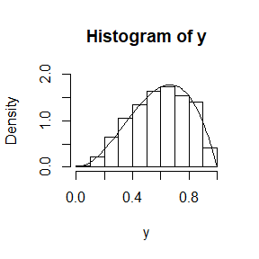

```r
generateBeta <- function(n,a,b){

  mx=(1-a)/(2-a-b)
  max=mx^(a-1)*(1-mx)^(b-1)/beta(a,b)
  c=max+1

  j<-k<-0; y <- numeric(n)
  while (k < n) {
    u <- runif(1)
    j <- j + 1
    x <- runif(1) #random variate from g
    if (x^(a-1)*(1-x)^(b-1)/beta(a,b) > c*u) {
    #we accept x
    k <- k + 1
    y[k] <- x
    }
  }

  return(y)
}

#example
y<-generateBeta(1000,3,2)
hist(y,prob = TRUE,ylim=c(0,2))
x <- seq(0, 1, .01)
#lines
lines(x, x^2*(1-x)^1/beta(3,2))
```

## question3.12

Simulate a continuous Exponential-Gamma mixture. Suppose that the rate parameter has $Gamma(r, \beta)$ distribution and Y has Exp distribution. That is,$(Y|\Lambda=\lambda)~f_{y}(y|\lambda)=\lambda e^{-\lambda y}$ . Generate 1000 random observations from this mixture with r = 4 and ?? = 2.

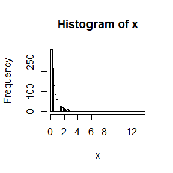

```r
set.seed(12345)
n <- 1e3; r <- 4; beta <- 2
#lambda
lambda <- rgamma(n, r, beta)
x<-rexp(n,lambda)
hist(x,breaks = 50)
```

## The 3th Homework

## question 5.4

Write a function to compute a Monte Carlo estimate of the Beta(3, 3) cdf, and use the function to estimate F(x) for x = 0.1, 0.2, . . . , 0.9. Compare the estimates with the values returned by the pbeta function in R.

```r
mypbeta<-function(a,b,x){
  m=20000
  u=runif(m/2,min=0,max=x)
  u1=1-u
  g=1/beta(a,b)*u^(a-1)*(1-u)^(b-1)*x
  g1=1/beta(a,b)*u1^(a-1)*(1-u1)^(b-1)*x
  theta=(mean(g)+mean(g1))/2
  sd=sd(c(g,g1))/m
  return(list("theta"=theta,"sd"=sd))
}
x=seq(0.1,0.9,by=0.1)
MC=numeric(9)
sd=numeric(9)
for(i in 1:9){
  result=mypbeta(3,3,x[i])
  MC[i]=result[[1]]
  sd[i]=result[[2]]
}
pBeta=pbeta(x,3,3)
cdf=rbind(MC,pBeta)
knitr::kable(cdf,col.names=x)
```

|  | 0.1 | 0.2 | 0.3 | 0.4 | 0.5 | 0.6 | 0.7 | 0.8 | 0.9 |
| --- | --- | --- | --- | --- | --- | --- | --- | --- | --- |
| MC | 0.0085203 | 0.0570468 | 0.1624034 | 0.3169618 | 0.5023159 | 0.6868109 | 0.8409287 | 0.9446431 | 0.9927234 |
| pBeta | 0.0085600 | 0.0579200 | 0.1630800 | 0.3174400 | 0.5000000 | 0.6825600 | 0.8369200 | 0.9420800 | 0.9914400 |

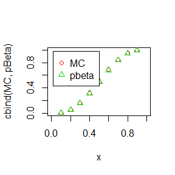

```r
matplot(x,cbind(MC,pBeta),col=2:3,pch=1:2,xlim=c(0,1))
legend("topleft", inset=.05,legend=c("MC","pbeta"),col=2:3,pch=1:2)
```

## question 5.9

Implement a function to generate samples from a Rayleigh distribution,using antithetic variables. What is the percent reduction in variance of (X+X’)/2compared with (X1+X2)/2 for independent X1, X2?

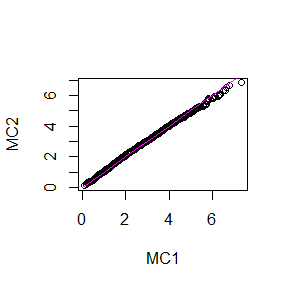

```r
myrRayleigh<-function(n,sigma,antithetic=TRUE){
  u=runif(n/2)
  if(!antithetic)
    {v=runif(n/2)}
  else
    {v=1-u}
  u=c(u,v)
  x=sqrt(-2*sigma^2*log(1-u))
  return(x)
}
n=1000
set.seed(12345)
MC1=myrRayleigh(n,2,antithetic = TRUE)
set.seed(12345)
MC2=myrRayleigh(n,2,antithetic = FALSE)
qqplot(MC1,MC2)
y=seq(0,10)
lines(y,y,col=6)
```

```r
1-var(MC1)/var(MC2)
```

```
## [1] -0.08018977
```

## question 5.13

Find two importance functions f1 and f2 that are supported on (1,??) and are close to $g(x) = \frac{x^2}{\sqrt{2\pi}} e^{-{x^2}/2}, x > 1$. Which of your two importance functions should produce the smaller variance in estimating $\int_1^\infty\frac{x^2}{\sqrt{2\pi}} e^{-{x^2}/2}\,dx$ by importance sampling? Explain.

## question5.14

Obtain a Monte Carlo estimate of $\int_1^\infty\frac{x^2}{\sqrt{2\pi}} e^{-{x^2}/2}\,dx$ by importance sampling.

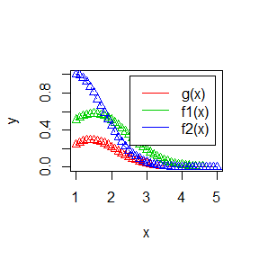

```r
x=seq(1,5,0.1)
g=function(x)x^2/sqrt(2*pi)*exp(-(x^2)/2)
f1=function(x)1/((1-pnorm(-0.5))*sqrt(2*pi))*exp(-((x-1.5)^2)/2)
f2=function(x)x*exp(-((x^2)-1)/2)
plot(x,g(x),col=2,type="o",ylim=c(0,1),lty=2,ylab="y",pch=2)
lines(x,f1(x),col=3,type="o",lty=2,pch=2)
lines(x,f2(x),col=4,,type="o",lty=2,pch=2)
legend("topright",inset=.05,legend=c("g(x)","f1(x)","f2(x)"),lty=1,col=2:4,horiz=FALSE)
```

```r
n=2000
set.seed(12345)
X=rnorm(1.5*n,mean=1.5,sd=1)
X=X[X>1]
X=X[1:n]
theta1=mean(g(X)/f1(X))
sd1=sd(g(X)/f1(X))/n
theta1
```

```
## [1] 0.4022873
```

```r
sd1
```

```
## [1] 5.696669e-05
```

```r
set.seed(12345)
Z=rexp(n,rate=0.5)
Y=sqrt(Z+1)
theta2=mean(g(Y)/f2(Y))
sd2=sd(g(Y)/f2(Y))/n
theta2
```

```
## [1] 0.3986784
```

```r
sd2
```

```
## [1] 6.132641e-05
```

## The 4th Homework

## question 6.9

Let X be a non-negative random variable with $\mu < E[X] < \infty$. For a random sample x1, . . . , xn from the distribution of X, the Gini ratio is defined by
$$G=\frac1{2n^2\mu} \sum_{j=1}^n\sum_{i=1}^n |x_i-x_j|.$$

The Gini ratio is applied in economics to measure inequality in income distribution. Note that G can be written in terms of the order statistics x(i) as
$$G=\frac1{n^2\mu}\sum_{i=1}^n (2i-n-1)x_{(i)}.$$

If the mean is unknown, let $\hat{G}$ be the statistic G with replaced by x. Estimate by simulation the mean, median and deciles of $\hat{G}$ if X is standard lognormal. Repeat the procedure for the uniform distribution and Bernoulli(0.1). Also construct density histograms of the replicates in each case.

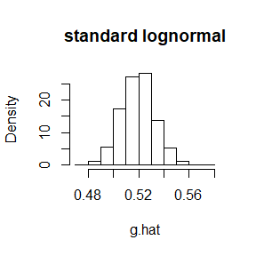

```r
m <- 1e3; n <- 1e3; set.seed(123)

##X is standard lognormal
g.hat <-  numeric(m)
for(i in 1:m){
  x <- rlnorm(n)
  xorder <- sort(x)
  for(j in 1:n){
    g.hat[i] <- g.hat[i] + (2*j-n-1)*xorder[j]
  }
  g.hat[i] <- g.hat[i]/(n*n*mean(xorder))
}
hist(g.hat,freq = F, main = "standard lognormal" )
```

```r
g.est <- mean(g.hat)
g.est
```

```
## [1] 0.5195845
```

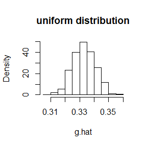

```r
##X is uniform distribution
g.hat <-  numeric(m)
for(i in 1:m){
  x <- runif(n)
  xorder <- sort(x)
  for(j in 1:n){
    g.hat[i] <- g.hat[i] + (2*j-n-1)*xorder[j]
  }
  g.hat[i] <- g.hat[i]/(n*n*mean(xorder))
}
hist(g.hat,freq = F, main = "uniform distribution")
```

```r
g.est <- mean(g.hat)
g.est
```

```
## [1] 0.3331501
```

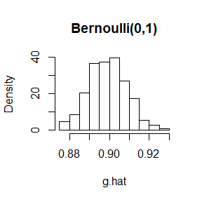

```r
##X is Bernoulli(0,1) distribution
g.hat <-  numeric(m)
for(i in 1:m){
  x <- rbinom(n,size=1,prob = 0.1)
  xorder <- sort(x)
  for(j in 1:n){
    g.hat[i] <- g.hat[i] + (2*j-n-1)*xorder[j]
  }
  g.hat[i] <- g.hat[i]/(n*n*mean(xorder))
}
hist(g.hat,freq = F,main = "Bernoulli(0,1)")
```

```r
g.est <- mean(g.hat)
g.est
```

```
## [1] 0.899542
```

## question6.10

Construct an approximate 95% confidence interval for the Gini ratio = E[G] if X is lognormal with unknown parameters. Assess the coverage rate of the estimation procedure with a Monte Carlo experiment

```r
m <- 1e2; n <- 1e4; set.seed(123)

##X is lognormal with unknown parameters
g.hat <-  numeric(m)
for(i in 1:m){
  x <- rlnorm(n)
  xorder <- sort(x)
  for(j in 1:n){
    g.hat[i] <- g.hat[i] + (2*j-n-1)*xorder[j]
  }
  g.hat[i] <- g.hat[i]/(n*n*mean(xorder))
}
g.est <- mean(g.hat)

CI<-c(mean(g.hat)-qt(0.975,1e4-2)*sd(g.hat),mean(g.hat)+qt(0.975,1e4-2)*sd(g.hat)) #approximate 95% confidence interval
mean(g.hat>=CI[1]&g.hat<=CI[2]) #coverage rate
```

```
## [1] 0.95
```

Conclusion:coverage rate of the estimation procedure with a Monte Carlo experiment is 0.95.

## question6.B

Tests for association based on Pearson product moment correlation , Spearman??s rank correlation coefficient $\rho_{s}$, or Kendalls coefficient, are implemented in cor.test. Show (empirically) that the nonparametric tests based on $\rho_{s}$ or are less powerful than the correlation test when the sampled distribution is bivariate normal. Find an example of an alternative (a bivariate distribution (X, Y ) such that X and Y are dependent) such that at least oneof the nonparametric tests have better empirical power than the correlation test against this alternative.

```r
library(mvtnorm)
m <- 1e3; n <- 5e2

##test1
test1 <- function(md){
  mean<-c(0,0)
  sigma<-matrix(c(1,0.1,0.1,1),nrow=2)
  p.val1 <- numeric(m)
  for(i in 1:m){
    x <- rmvnorm(n,mean,sigma)
    p.val1[i] <- cor.test(x[,1],x[,2],method = md)$p.value
  }
  print(mean(p.val1<=0.05))
}
test1("pearson")
```

```
## [1] 0.616
```

```r
test1("kendall")
```

```
## [1] 0.574
```

```r
test1("spearman")
```

```
## [1] 0.581
```

```r
##test2
test2 <- function(md){

  p.val2 <- numeric(m)
  for(i in 1:m){
    x<-rnorm(n)
    a<-rbinom(n,1,0.5)
    v<-2*a-1
    y<-data.frame(x=x,y=v*x)
    p.val2[i] <-cor.test(y[,1],y[,2],method = md)$p.value
  }
  print(mean(p.val2<=0.05))
}
test2("pearson")
```

```
## [1] 0.259
```

```r
test2("kendall")
```

```
## [1] 0.273
```

```r
test2("spearman")
```

```
## [1] 0.149
```

Conclusion: because power(test1) > power(test2) , this example of an alternative have better empirical power than the correlation test against this alternative.

## The 5th Homework

## question 7.1

Compute a jackknife estimate of the bias and the standard error of the correlation statistic in Example 7.2

```r
library(boot);  set.seed(12345)
n=15

#this data is from page-185
LAST <- c(576, 635, 558, 578, 666, 580, 555, 661, 651, 605, 653, 575, 545, 572, 594)
GPA  <- c(339, 330, 281, 303, 344, 307, 300, 343, 336, 313, 312, 274, 276, 288, 296)
law <- data.frame(LAST,GPA)

b.cor <- function(data,i){
  d <- data[i,]
  return(cor(d$LAST,d$GPA))
}

theta.hat <- b.cor(law,1:n)
theta.jack <- numeric(n)

for(i in 1:n){
theta.jack[i] <- b.cor(law,(1:n)[-i])
}
bias.jack <- (n-1)*(mean(theta.jack)-theta.hat)
se.jack <- sqrt((n-1)*mean((theta.jack-theta.hat)^2))
round(c(original=theta.hat,bias=bias.jack,
se=se.jack),3)
```

```
## original     bias       se
##    0.776   -0.006    0.143
```

conclution: the bias is -0.006 and the standard error is 0.143

## question 7.3

Refer to Exercise 7.4. Compute 95% bootstrap confidence intervals for the mean time between failures by the standard normal, basic, percentile, and BCa methods. Compare the intervals and explain why they may differ.

```r
library(boot)
set.seed(12345)

boot.mean <- function(x,i) mean(x[i]) #the statistic of boot

n <- 12
x <-c(3, 5, 7, 18, 43, 85, 91, 98, 100, 130, 230, 487) #12 observations

ci.norm<-ci.basic<-ci.perc<-ci.bca<-c(NA,n)  # initialize

de <- boot(data=x, statistic=boot.mean, R = 1e3)
ci <- boot.ci(de,type=c("norm","basic","perc","bca"))
ci.norm[]<-ci$norm[2:3]
ci.basic[]<-ci$basic[4:5]
ci.perc[]<-ci$percent[4:5]
ci.bca[]<-ci$bca[4:5]

#by the standard normal, basic, percentile, and BCa methods
cat('norm = ', ci.norm,
'basic = ', ci.basic,
'perc = ',ci.perc,
'BCa = ',ci.bca)
```

```
## norm =  36.70056 182.5638 basic =  25.14049 167.4979 perc =  48.66878 191.0262 BCa =  58.91667 243.3362
```

## question7.8

Refer to Exercise 7.7. Obtain the jackknife estimates of bias and standard error of theta.

```r
library("bootstrap")
m=5; n=88

getTheta <- function(data,i){
  d <- data[i,]
  cov.d  <- cov(d)
  lamba <- eigen(cov.d)$values
  theta <- max(lamba)/sum(lamba)

  return(theta)
  }

theta.hat <- getTheta(scor,1:n)
theta.jack <- numeric(n)

for(i in 1:n){
theta.jack[i] <- getTheta(scor,(1:n)[-i])
}
bias.jack <- (n-1)*(mean(theta.jack)-theta.hat)
se.jack <- sqrt((n-1)*mean((theta.jack-theta.hat)^2))
round(c(original=theta.hat,bias=bias.jack,
se=se.jack),3)
```

```
## original     bias       se
##    0.619    0.001    0.050
```

conclusion: the bias id 0.001, the se is 0.050

## question7.11

In Example 7.18, leave-one-out (n-fold) cross validation was used to select the best fitting model. Use leave-two-out cross validation to compare the models.

```r
library(DAAG)
attach(ironslag)

n <- length(magnetic)

ke1 <- ke2 <- ke3 <- ke4 <- 0
ge1 <- ge2 <- ge3 <- ge4 <- 0
sqrte1 <- sqrte2 <- sqrte3 <- sqrte4 <- 0   #the sqrt of errors


for(k in 1:(n-1))

  for(g in (k+1):n){                        #leave-two-out

    y <- magnetic[-k][-g]
    x <- chemical[-k][-g]

    J1 <- lm(y ~ x)
    yhat1k <- J1$coef[1] + J1$coef[2] * chemical[k]
    yhat1g <- J1$coef[1] + J1$coef[2] * chemical[g]
    ke1 <- magnetic[k] - yhat1k
    ge1 <- magnetic[g] - yhat1g
    sqrte1 = sqrte1 +  ke1^2 + ge1^2


    J2 <- lm(y ~ x + I(x^2))
    yhat2k <- J2$coef[1] + J2$coef[2] * chemical[k] + J2$coef[3] * chemical[k]^2
    yhat2g <- J2$coef[1] + J2$coef[2] * chemical[g] + J2$coef[3] * chemical[g]^2
    ke2 <- magnetic[k] - yhat2k
    ge2 <- magnetic[g] - yhat2g
    sqrte2 = sqrte2 +  ke2^2 + ge2^2

    J3 <- lm(log(y) ~ x)
    logyhat3k <- J3$coef[1] + J3$coef[2] * chemical[k]
    logyhat3g <- J3$coef[1] + J3$coef[2] * chemical[g]
    yhat3k <- exp(logyhat3k)
    yhat3g <- exp(logyhat3g)
    ke3 <- magnetic[k] - yhat3k
    ge3 <- magnetic[g] - yhat3g
    sqrte3 = sqrte3 +  ke3^2 + ge3^2



    J4 <- lm(log(y) ~ log(x))
    logyhat4k <- J4$coef[1] + J4$coef[2] * log(chemical[k])
    logyhat4g <- J4$coef[1] + J4$coef[2] * log(chemical[g])
    yhat4k <- exp(logyhat4k)
    yhat4g <- exp(logyhat4g)
    ke4 <- magnetic[k] - yhat4k
    ge4 <- magnetic[g] - yhat4g
    sqrte4 = sqrte4 +  ke4^2 + ge4^2


    }

#sqrte is the total errors
sqrte1/(n*(n-1))
```

```
## (Intercept)
##    19.10205
```

```r
sqrte2/(n*(n-1))
```

```
## (Intercept)
##    16.96715
```

```r
sqrte3/(n*(n-1))
```

```
## (Intercept)
##    18.06395
```

```r
sqrte4/(n*(n-1))
```

```
## (Intercept)
##    20.07774
```

conclusion: We use leave-one-out (n-fold) and leave-two-out cross validation to compare the models.

```
     leave-one-out                 leave-two-out
```

modelA: 19.55644 19.10205

modelB: 17.85248 16.96715

modelC: 18.44188 18.06395

modelD: 20.45424 20.07774

we can get the Result approximation.

## The 6th Homework

## question 8.1

Implement the two-sample Cramer-von Mises test for equal distributions as a permutation test. Apply the test to the data in Examples 8.1 and 8.2.

```r
attach(chickwts)
x <- sort(as.vector(weight[feed == "soybean"]))
y <- sort(as.vector(weight[feed == "linseed"]))
detach(chickwts)
z <- c(x, y)

#Cramer-von Mises test
cramer.test <- function(X,Y){
  m = length(X)
  n = length(Y)

  FM = ecdf(X)
  GN = ecdf(Y)

  sumx = sum(   (FM(X)-GN(X))^2  )
  sumy = sum(   (FM(Y)-GN(Y))^2  )

  static = (sumx + sumy)*m*n/sqrt((m+n))

  return(static)
}


R <- 999
K <- 1:26
n<-length(x)
set.seed(12345)
reps <- numeric(R)

library(nortest)
c0 <- cramer.test(x,y)

for (i in 1:R) {
 k <- sample(K, size = n, replace = FALSE)
 x1 <- z[k];y1 <- z[-k]
 z1 <- c(x1,y1)
 reps[i] <- cramer.test(x1,y1)
}

 p <- mean(abs(c(c0, reps)) >= abs(c0))
 p
```

```
## [1] 0.407
```

## question

Design experiments for evaluating the performance of the NN,energy, and ball methods in various situations. 1 Unequal variances and equal expectations 2 Unequal variances and unequal expectations 3 Non-normal distributions: t distribution with 1 df (heavy-tailed distribution), bimodel distribution (mixture of two normal distributions) 4 Unbalanced samples (say, 1 case versus 10 controls) 5 Note: The parameters should be choosen such that the powersare distinguishable (say, range from 0.3 to 0.9).

```r
library(RANN)
library(boot)
library(energy)
library(Ball)
m <- 1e3; k<-3; p<-2; mu <- 0.5; su <- 0.75; set.seed(12345)
n1 <- n2 <- 50; R<-999; n <- n1+n2; N = c(n1,n2)
n3 <- 10; n4 <-100; M <- c(n3,n4)  #Unbalanced samples

Tn <- function(z, ix, sizes,k) {
   n1 <- sizes[1]; n2 <- sizes[2]; n <- n1 + n2
   if(is.vector(z)) z <- data.frame(z,0);
   z <- z[ix, ];
   NN <- nn2(data=z, k=k+1) # what's the first column?
   block1 <- NN$nn.idx[1:n1,-1]
   block2 <- NN$nn.idx[(n1+1):n,-1]
   i1 <- sum(block1 < n1 + .5); i2 <- sum(block2 > n1+.5)
   (i1 + i2) / (k * n)
}

eqdist.nn <- function(z,sizes,k){
  boot.obj <- boot(data=z,statistic=Tn,R=R,
  sim = "permutation", sizes = sizes,k=k)
  ts <- c(boot.obj$t0,boot.obj$t)
  p.value <- mean(ts>=ts[1])
  list(statistic=ts[1],p.value=p.value)
}

#Unequal variances and equal expectations
# p.values1 <- matrix(NA,m,3)
# for(i in 1:m){
#   x <- matrix(rnorm(n1*p),ncol=p);
#   y <- cbind(rnorm(n2),rnorm(n2,sd=su));
#   z <- rbind(x,y)
#   p.values1[i,1] <- eqdist.nn(z,N,k)$p.value
#   p.values1[i,2] <- eqdist.etest(z,sizes=N,R=R)$p.value
#   p.values1[i,3] <- bd.test(x=x,y=y,R=999,seed=i*12345)$p.value
# }
#
# #Unequal variances and unequal expectations
# p.values2 <- matrix(NA,m,3)
# for(i in 1:m){
#   x <- matrix(rnorm(n1*p),ncol=p);
#   y <- cbind(rnorm(n2),rnorm(n2,mean=mu,sd=su));
#   z <- rbind(x,y)
#   p.values2[i,1] <- eqdist.nn(z,N,k)$p.value
#   p.values2[i,2] <- eqdist.etest(z,sizes=N,R=R)$p.value
#   p.values2[i,3] <- bd.test(x=x,y=y,R=999,seed=i*12345)$p.value
# }
#
# #t distribution with 1 df (heavy-tailed distribution)
# p.values3 <- matrix(NA,m,3)
# for(i in 1:m){
#   x <- matrix(rt(n1*p,df=1),ncol=p);
#   y <- cbind(rt(n2,df=1),rt(n2,df=0.8));
#   z <- rbind(x,y)
#   p.values3[i,1] <- eqdist.nn(z,N,k)$p.value
#   p.values3[i,2] <- eqdist.etest(z,sizes=N,R=R)$p.value
#   p.values3[i,3] <- bd.test(x=x,y=y,R=999,seed=i*12345)$p.value
# }
#
# #Unbalanced samples (say, 1 case versus 10 controls)
# p.values4 <- matrix(NA,m,3)
# for(i in 1:m){
#   x <- matrix(rnorm(n3*p),ncol=p);
#   y <- cbind(rnorm(n4),rnorm(n4,mean = mu));
#   z <- rbind(x,y)
#   p.values4[i,1] <- eqdist.nn(z,M,k)$p.value
#   p.values4[i,2] <- eqdist.etest(z,sizes=M,R=R)$p.value
#   p.values4[i,3] <- bd.test(x=x,y=y,R=999,seed=i*12345)$p.value
# }
#
# alpha <- 0.1;
# pow1 <- colMeans(p.values1<alpha)
# pow2 <- colMeans(p.values2<alpha)
# pow3 <- colMeans(p.values3<alpha)
# pow4 <- colMeans(p.values4<alpha)
# pow1
# pow2
# pow3
# pow4
```

## question 9.3

Use the Metropolis-Hastings sampler to generate random variables from a standard Cauchy distribution. Discard the first 1000 of the chain, and compare the deciles of the generated observations with the deciles of the standard Cauchy distribution (seeq cauchy or qt with df=1). Recall that a Cauchy distribution has density function $f(x)=\frac1{\theta\pi(1+[(x-\eta)/\theta]^2)}$. The standard Cauchy has the Cauchy density. (Note that the standard Cauchy density is equal to the Student t density with one degree of freedom.)

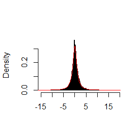

```r
set.seed(123456)
m=50000
discard=1000

# cauchy density
cauchy<-function(x, thata=0, gamma=1){

  cau_y<-1/(pi*gamma*(1+((x-thata)/gamma)^2))
  return(cau_y)

}

chain<-c(0)
for(i in 1:m){
    proposal<-chain[i]+runif(1, min=-1, max=1)
    accept<-runif(1)<cauchy(proposal)/cauchy(chain[i])
    chain[i+1]<-ifelse(accept==T, proposal, chain[i])
}

#plot
y <- chain[discard:m]
hist(y, breaks="scott", main="", xlab="", freq=FALSE)

a <- ppoints(100)
QR=tan((a-0.5)*pi)
lines(QR, cauchy(QR),col='red')
```

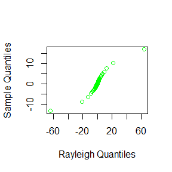

```r
b <- ppoints(1000)
Q <- quantile(y, b)
qqplot(QR, Q, main="",xlab="Rayleigh Quantiles", ylab="Sample Quantiles",col='green')
```

## The 7th Homework

## question 11.4

Find the intersection points A(k) in (0,k) of the curves
$$S_{k-1}(a)=p \left( t(k-1)>\sqrt{\frac{a^2(k-1)}{k-a^2}} \right)$$
and
$$S_{k}(a)=p \left( t(k)>\sqrt{\frac{a^2k}{k+1-a^2}} \right)$$
for k = 4 : 25, 100, 500, 1000, where t(k) is a Student t random variable with k degrees of freedom. (These intersection points determine the critical values for a t-test for scale-mixture errors proposed by Sz??ekely [260].)

```r
kset <- c(4:25,100,500,1000)   #chose k
res <- numeric(25)
#f is the functon
f <- function(x){
  k1 = ( x*x*(k-1)/(k-x*x) )^0.5
  k2 = ( x*x*k/(k+1-x*x) )^0.5
  y = pt(k1,df=k-1)-pt(k2,df=k)
  return(y)
}
#k = 4 : 25, 100, 500, 1000
for(i in 1:25){
  k <- kset[i]
  res[i] <- uniroot(f,c(1e-1,k^0.5-1e-1))$root  #res can't be 0
}

kr <- cbind(kset,res)
kr
```

```
##       kset       res
##  [1,]    4  1.492103
##  [2,]    5  1.533582
##  [3,]    6  1.562744
##  [4,]    7  1.584429
##  [5,]    8  1.601183
##  [6,]    9  1.614536
##  [7,]   10  1.625366
##  [8,]   11  1.634415
##  [9,]   12  1.642017
## [10,]   13  1.648547
## [11,]   14  1.654170
## [12,]   15  1.659098
## [13,]   16  1.663444
## [14,]   17  1.667283
## [15,]   18  1.670738
## [16,]   19  1.673795
## [17,]   20  1.676614
## [18,]   21  1.679154
## [19,]   22  1.681472
## [20,]   23  1.683594
## [21,]   24  1.685569
## [22,]   25  1.687336
## [23,]  100  9.900000
## [24,]  500 22.260680
## [25,] 1000 31.522777
```

# question9.6

Rao [220, Sec. 5g] presented an example on genetic linkage of 197 animals in four categories (also discussed in [67, 106, 171, 266]). The group sizes are (125, 18, 20, 34). Assume that the probabilities of the corresponding multinomial distribution are $1/2+\theta/4,(1-\theta)/4,(1-\theta)/4,\theta/4$. Estimate the posterior distribution of ?? given the observed sample, using one of the methods in this chapter.

```r
m <- 1e4
discard <- 200
k<-4
x0 <- c(0.2, 0.4, 0.6, 0.8)

#Gelman-Rubin method of monitoring convergence
Gelman.Rubin <- function(psi) {
    psi <- as.matrix(psi)
    n <- ncol(psi)
    k <- nrow(psi)
    psi.means <- rowMeans(psi)
    B <- n * var(psi.means)
    psi.w <- apply(psi, 1, "var")
    W <- mean(psi.w)
    v.hat <- W*(n-1)/n + (B/n)
    r.hat <- v.hat / W #G-R statistic
    return(r.hat)
}


prob <- function(y, win) {
        if (y < 0 || y >= 1)
            return (0)
        return(
          (1/2+y/4)^win[1] * ((1-y)/4)^win[2] * ((1-y)/4)^win[3] * (y/4)^win[4]
          )
}


normal.chain <- function(m, w){

  u <- runif(m)
  v <- runif(m, -w, w)
  x <- numeric(m)

  x[1] <- w
  win=c(125,18,20,34)

  for (i in 2:m) {
    y <- x[i-1] + v[i]
    if (u[i] <= prob(y, win) / prob(x[i-1], win))
      x[i] <- y
    else
      x[i] <- x[i-1]
  }
  return(x)
}

X <- matrix(0, nrow=k, ncol=m)
theta <- numeric(k)

for (i in 1:k){
      X[i, ] <- normal.chain(m, x0[i])
      theta[i] <- mean( X[i,(discard+1):m] )
}
theta
```

```
## [1] 0.6240052 0.6245178 0.6227991 0.6225741
```

```r
psi <- t(apply(X, 1, cumsum))
for (i in 1:nrow(psi))
       psi[i,] <- psi[i,] / (1:ncol(psi))
print(Gelman.Rubin(psi))
```

```
## [1] 1.017155
```

```r
#par(mfrow=c(2,2))
#for (i in 1:k)
    #plot(psi[i, (discard+1):m], type="l", xlab=i, ylab=bquote(psi))
#par(mfrow=c(1,1))

#Sequence of the Gelman-Rubin
rhat <- rep(0, m)
for (j in (discard+1):m)
    rhat[j] <- Gelman.Rubin(psi[,1:j])
#plot(rhat[(discard+1):m], type="l", xlab="", ylab="R")
#abline(h=1.1, lty=2)
```

## The 8th Homework

## question 11.6

Write a function to compute the cdf of the Cauchy distribution, which has density
$$\frac{1}{\theta\pi(1+[(x-\eta)/\theta]^2)}, - \infty < X < \infty$$
where?? > 0. Compare your results to the results from the R function pcauchy.(Also see the source code in pcauchy.c.)

```r
#the function of caushy
f <- function(x,theta,eta){
    y <- 1/(theta*pi*(1+((x-eta)/theta)^2))
}

res_zero <- integrate(f, lower=-Inf, upper=0,rel.tol=.Machine$double.eps^0.25,theta=1,eta=0)
res_inf <- integrate(f, lower=-Inf, upper=Inf,rel.tol=.Machine$double.eps^0.25,theta=1,eta=0)

res_zero
```

```
## 0.5 with absolute error < 6.2e-05
```

```r
res_inf
```

```
## 1 with absolute error < 1.6e-10
```

conclusion:results is the same to the results from the R function pcauchy

# question 2

A-B-O blood type problem,Let the three alleles be A, B, and O. Observed data: $n_{A\cdot}=n_{AA}+n_{AO}=28$ (A-type), $n_{B\cdot}=n_{BB}+n_{BO}=24$ (B-type), $n_{OO}=41$ (O-type), $n_{AB}=70$ Use EM algorithm to solve MLE of p and q (consider missing data $n_{AA}$ and $n_{BB}$B). Record the maximum likelihood values in M-steps, are they increasing?

```r
N<-100
tol <- 1e-10
Na. = 28; Nb. = 24; Noo = 41; Nab = 70

res_old <- c(0.1,0.1) #initial est. for p and q

#A function to be minimized
fr <- function(res){

  p0=res_old[1]; q0=res_old[2]; r0=1-p0-q0
  p=res[1]; q=res[2]; r=1-p-q

  y =  2*Na.*log(p) + 2*Nb.*log(q) + 2*Noo*log(r) + Nab*log(2*p*q) + 2*r0/(p0+2*r0)*Na.*log(2*r/p) +                                     2*r0/(q0+2*r0)*Nb.*log(2*r/q)

  return(-y)
}

#A function to return the gradient for the "BFGS", "CG" and "L-BFGS-B" methods
grr <- function(res){

  p0=res_old[1]; q0=res_old[2]; r0=1-p0-q0
  p=res[1]; q=res[2]; r=1-p-q

  yp= - ( 2*Na./p - 2*Noo/r + Nab/p - 2*r0/(p0+2*r0)*Na.*(1/r+1/p) - 2*r0/(q0+2*r0)*Nb.*(1/r) )
  yq= - ( 2*Nb./q - 2*Noo/r + Nab/q - 2*r0/(p0+2*r0)*Na.*(1/r) - 2*r0/(q0+2*r0)*Nb.*(1/r+1/q) )

  return ( c(yp,yq) )

}

#p=res[1];q=res[2];r=1-p-q
for(j in 1:N){


   res <- optim(c(0.1,0.1), fr,grr, method = "L-BFGS-B", lower = c(0.01,0.01), upper = c(0.49,0.49) )$par


   if (sum(abs(res - res_old)/res_old) < tol) break

   res_old <- res

   print(res_old)
}
```

```
## [1] 0.3056667 0.2926737
## [1] 0.3242866 0.3080029
## [1] 0.3268966 0.3100750
## [1] 0.3272782 0.3103751
## [1] 0.3273342 0.3104191
## [1] 0.3273424 0.3104256
## [1] 0.3273436 0.3104265
## [1] 0.3273438 0.3104267
## [1] 0.3273438 0.3104267
## [1] 0.3273438 0.3104267
## [1] 0.3273438 0.3104267
## [1] 0.3273438 0.3104267
```

Conclusion??p=0.3273438??q=0.3104267; r=0.3622295

## The 9th Homework

## page_204

## 3

Use both for loops and lapply() to fit linear models to the mtcars using the formulas stored in this list:

```r
library(datasets)
formulas <- list(
   mtcars$mpg ~ mtcars$disp,
   mtcars$mpg ~ I(1 / mtcars$disp),
   mtcars$mpg ~ mtcars$disp + mtcars$wt,
   mtcars$mpg ~ I(1 / mtcars$disp) + mtcars$wt
)

rsq <- function(mod){summary(mod)$r.squared}

 #lapply
lms <- lapply(formulas,lm)
lms
```

```
## [[1]]
##
## Call:
## FUN(formula = X[[i]])
##
## Coefficients:
## (Intercept)  mtcars$disp
##    29.59985     -0.04122
##
##
## [[2]]
##
## Call:
## FUN(formula = X[[i]])
##
## Coefficients:
##      (Intercept)  I(1/mtcars$disp)
##            10.75           1557.67
##
##
## [[3]]
##
## Call:
## FUN(formula = X[[i]])
##
## Coefficients:
## (Intercept)  mtcars$disp    mtcars$wt
##    34.96055     -0.01772     -3.35083
##
##
## [[4]]
##
## Call:
## FUN(formula = X[[i]])
##
## Coefficients:
##      (Intercept)  I(1/mtcars$disp)         mtcars$wt
##           19.024          1142.560            -1.798
```

```r
#loop
r2 <- numeric(4)
for (i in 1:4){
  LM <- lm(formulas[[i]])
  print(LM)
  r2[i] = rsq(LM)
}
```

```
##
## Call:
## lm(formula = formulas[[i]])
##
## Coefficients:
## (Intercept)  mtcars$disp
##    29.59985     -0.04122
##
##
## Call:
## lm(formula = formulas[[i]])
##
## Coefficients:
##      (Intercept)  I(1/mtcars$disp)
##            10.75           1557.67
##
##
## Call:
## lm(formula = formulas[[i]])
##
## Coefficients:
## (Intercept)  mtcars$disp    mtcars$wt
##    34.96055     -0.01772     -3.35083
##
##
## Call:
## lm(formula = formulas[[i]])
##
## Coefficients:
##      (Intercept)  I(1/mtcars$disp)         mtcars$wt
##           19.024          1142.560            -1.798
```

```r
#lapply
print("the R2 of lapply ")
```

```
## [1] "the R2 of lapply "
```

```r
unlist( lapply(lms,rsq) )
```

```
## [1] 0.7183433 0.8596865 0.7809306 0.8838038
```

```r
#lapply
print("the R2 of loop ")
```

```
## [1] "the R2 of loop "
```

```r
r2
```

```
## [1] 0.7183433 0.8596865 0.7809306 0.8838038
```

## 4

Fit the model mpg ~ disp to each of the bootstrap replicates of mtcars in the list below by using a for loop and lapply().Can you do it without an anonymous function?

```r
library(datasets)
set.seed(12345)
bootstraps <- lapply(1:10, function(i) {
    rows <- sample(1:nrow(mtcars), rep = TRUE)
    mtcars[rows,]
})
 #lapply
lms <-lapply(1:10,function(i){
  cars <- bootstraps[i]
  cars <- cars[[1]]
  coe <- lm(cars$mpg ~ cars$disp)
})
lms
```

```
## [[1]]
##
## Call:
## lm(formula = cars$mpg ~ cars$disp)
##
## Coefficients:
## (Intercept)    cars$disp
##    27.18917     -0.03496
##
##
## [[2]]
##
## Call:
## lm(formula = cars$mpg ~ cars$disp)
##
## Coefficients:
## (Intercept)    cars$disp
##    28.27433     -0.03751
##
##
## [[3]]
##
## Call:
## lm(formula = cars$mpg ~ cars$disp)
##
## Coefficients:
## (Intercept)    cars$disp
##    29.30162     -0.03752
##
##
## [[4]]
##
## Call:
## lm(formula = cars$mpg ~ cars$disp)
##
## Coefficients:
## (Intercept)    cars$disp
##    31.06115     -0.04546
##
##
```

[output cut: 43 more lines]

```
## lm(formula = cars$mpg ~ cars$disp)
##
## Coefficients:
## (Intercept)    cars$disp
##    28.67018     -0.03834
##
##
## [[10]]
##
## Call:
## lm(formula = cars$mpg ~ cars$disp)
##
## Coefficients:
## (Intercept)    cars$disp
##    30.43755     -0.04429
```

```r
#loop
r2<-numeric(10)
for(i in 1:10){
  cars <- bootstraps[[i]]
  LM <- lm(cars$mpg ~ cars$disp)
  print(LM)
  r2[i] <- rsq(LM)

}
```

```
##
## Call:
## lm(formula = cars$mpg ~ cars$disp)
##
## Coefficients:
## (Intercept)    cars$disp
##    27.18917     -0.03496
##
##
## Call:
## lm(formula = cars$mpg ~ cars$disp)
##
## Coefficients:
## (Intercept)    cars$disp
##    28.27433     -0.03751
##
##
## Call:
## lm(formula = cars$mpg ~ cars$disp)
##
## Coefficients:
## (Intercept)    cars$disp
##    29.30162     -0.03752
##
##
## Call:
## lm(formula = cars$mpg ~ cars$disp)
##
## Coefficients:
## (Intercept)    cars$disp
##    31.06115     -0.04546
##
##
## Call:
## lm(formula = cars$mpg ~ cars$disp)
##
## Coefficients:
## (Intercept)    cars$disp
##     30.8373      -0.0453
##
```

[output cut: 24 more lines]

```
##
## Call:
## lm(formula = cars$mpg ~ cars$disp)
##
## Coefficients:
## (Intercept)    cars$disp
##    28.67018     -0.03834
##
##
## Call:
## lm(formula = cars$mpg ~ cars$disp)
##
## Coefficients:
## (Intercept)    cars$disp
##    30.43755     -0.04429
```

```r
#lapply
print("the R2 of lapply ")
```

```
## [1] "the R2 of lapply "
```

```r
unlist( lapply(lms,rsq) )
```

```
##  [1] 0.7371990 0.6644658 0.6607375 0.7185377 0.7669859 0.7132957 0.6390637
##  [8] 0.7653332 0.6666068 0.7716368
```

```r
#lapply
print("the R2 of loop ")
```

```
## [1] "the R2 of loop "
```

```r
r2
```

```
##  [1] 0.7371990 0.6644658 0.6607375 0.7185377 0.7669859 0.7132957 0.6390637
##  [8] 0.7653332 0.6666068 0.7716368
```

## 5

For each model in the previous two exercises, extract R2 using the function below. ##did it in question 3 and question 4

## page_214

## 3

The following code simulates the performance of a t-test for non-normal data. Use sapply() and an anonymous function to extract the p-value from every trial.

```r
set.seed(12345)
trials <- replicate(
  100,
  t.test(rpois(10, 10), rpois(7, 10)),
  simplify = FALSE
)
trials[[1]]$p.value
```

```
## [1] 0.1788095
```

```r
sapply(1:100, function(i){trials[[i]]$p.value})
```

```
##   [1] 0.178809502 0.994262402 0.064786264 0.952716251 0.306702525
##   [6] 0.198224877 0.272315768 0.283722503 0.415010770 0.151957272
##  [11] 0.072625558 0.249014108 0.773938569 0.225693023 0.840328179
##  [16] 0.987492066 0.316112244 0.481740992 0.457889571 0.565871989
##  [21] 0.990401857 0.257905112 0.538178810 0.764364559 0.845551784
##  [26] 0.905726387 0.086725138 0.763639767 0.088857796 0.531422351
##  [31] 0.731524606 0.195574176 0.598923896 0.702134266 0.147168770
##  [36] 0.552598436 0.117002585 0.233188724 0.127240002 0.115791872
##  [41] 0.317030411 0.691674119 0.450514119 0.315343567 0.073583503
##  [46] 1.000000000 0.011099981 0.580714657 0.591841839 0.638287091
##  [51] 0.283349660 0.722557025 0.408819857 0.127117578 0.000507563
##  [56] 0.841418067 0.624022112 0.650656602 0.632088219 0.578419158
##  [61] 0.052008307 0.920025002 0.646534041 0.344836350 0.751638828
##  [66] 0.687324041 0.134492519 0.490444844 0.711864108 0.020394691
##  [71] 0.342792908 0.960823950 0.111337525 0.546907007 0.773231299
##  [76] 0.626303636 0.298304108 0.146218612 0.133931753 0.814393484
##  [81] 0.096839576 0.974929586 0.808056754 0.346709412 0.308443909
##  [86] 0.600935588 0.984471134 0.703069949 0.678262994 0.565803030
##  [91] 0.895621651 0.723438333 0.431024548 0.061331285 0.043636182
##  [96] 0.359298038 0.372409666 0.953012247 0.503028465 0.594358009
```

## 6

Implement a combination of Map() and vapply() to create an lapply() variant that iterates in parallel over all of its inputs and stores its outputs in a vector (or a matrix). What arguments should the function take?

```r
library(foreach)
library(datasets)

formulas <- list(
   mtcars$mpg ~ mtcars$disp,
   mtcars$mpg ~ I(1 / mtcars$disp),
   mtcars$mpg ~ mtcars$disp + mtcars$wt,
   mtcars$mpg ~ I(1 / mtcars$disp) + mtcars$wt
)

foreach(i=1:4) %do%
  lm(formulas[[i]])
```

```
## [[1]]
##
## Call:
## lm(formula = formulas[[i]])
##
## Coefficients:
## (Intercept)  mtcars$disp
##    29.59985     -0.04122
##
##
## [[2]]
##
## Call:
## lm(formula = formulas[[i]])
##
## Coefficients:
##      (Intercept)  I(1/mtcars$disp)
##            10.75           1557.67
##
##
## [[3]]
##
## Call:
## lm(formula = formulas[[i]])
##
## Coefficients:
## (Intercept)  mtcars$disp    mtcars$wt
##    34.96055     -0.01772     -3.35083
##
##
## [[4]]
##
## Call:
## lm(formula = formulas[[i]])
##
## Coefficients:
##      (Intercept)  I(1/mtcars$disp)         mtcars$wt
##           19.024          1142.560            -1.798
```

#### The 10th Homework

## question 4

Make a faster version of chisq.test() that only computes the chi-square test statistic when the input is two numeric vectors with no missing values. You can try simplifying chisq.test() or by coding from the mathematical definition (http://en.wikipedia.org/wiki/Pearson%27s_chi-squared_test).

```r
simple_chitest <- function(x,y){

     OK <- complete.cases(x, y)
     x <- factor(x[OK])
     y <- factor(y[OK])

     x <- table(x, y)

     if ((n <- sum(x)) == 0)
        stop("at least one entry of 'x' must be positive")

     nr <- as.integer(nrow(x))
     nc <- as.integer(ncol(x))
     sr <- rowSums(x)
     sc <- colSums(x)
     E <- outer(sr, sc, "*")/n

     STATISTIC <- sum((x - E)^2/E)
     PARAMETER <- (nr - 1L) * (nc - 1L)
     PVAL <- pchisq(STATISTIC, PARAMETER, lower.tail = FALSE)


     structure(list(statistic = STATISTIC, p.value = PVAL), class = "htest")
}

set.seed(123456)
x1<-sample(1:10,1000,replace = T)
x2<-sample(10:20,1000,replace = T)

#chisq.test
chisq.test(x1,x2)
```

```
##
##  Pearson's Chi-squared test
##
## data:  x1 and x2
## X-squared = 99.619, df = 90, p-value = 0.229
```

```r
##simple_chitest
simple_chitest(x1,x2)
```

```
##
##
##
## data:
## = 99.619, p-value = 0.229
```

```r
library(microbenchmark)
ts <- microbenchmark(chisq=chisq.test(x1,x2),simple_chitest=simple_chitest(x1,x2))
summary(ts)[,c(1,3,5,6)]
```

```
##             expr       lq   median      uq
## 1          chisq 518.6685 547.7795 618.002
## 2 simple_chitest 354.0010 368.6680 423.113
```

## question 5

Can you make a faster version of table() for the case of an input of two integer vectors with no missing values? Can you use it to speed up your chi-square test?

```r
simple_table <- function(x1,x2){

  f1 <- factor(x1)
  name1 <- levels(f1)
  f2 <- factor(x2)
  name2 <- levels(f2)


  dims = c(length(name1),length(name2))
  dimname = list(name1,name2)

  y<-array(0,dims,dimname)

  n1=length(f1)
  #n2=length(f2)
  #m1=length(name1)
  #m2=length(name2)

  for (i in 1:n1) {
    y[f1[i],f2[i]] = y[f1[i],f2[i]] + 1
  }
  y
}

#use simple_table to do simple_chitest2
simple_chitest2 <- function(x,y){

     OK <- complete.cases(x, y)
     x <- factor(x[OK])
     y <- factor(y[OK])

     x <- simple_table(x, y)

     if ((n <- sum(x)) == 0)
        stop("at least one entry of 'x' must be positive")

     nr <- as.integer(nrow(x))
     nc <- as.integer(ncol(x))
     sr <- rowSums(x)
     sc <- colSums(x)
     E <- outer(sr, sc, "*")/n

     STATISTIC <- sum((x - E)^2/E)
     PARAMETER <- (nr - 1L) * (nc - 1L)
     PVAL <- pchisq(STATISTIC, PARAMETER, lower.tail = FALSE)


     structure(list(statistic = STATISTIC, p.value = PVAL), class = "htest")
}


set.seed(123456)
x1<-sample(1:10,1000,replace = T)
x2<-sample(11:20,1000,replace = T)

#table
ptm <- proc.time()
table(x1,x2)
```

```
##     x2
## x1   11 12 13 14 15 16 17 18 19 20
##   1   6 10  7 11 11 16 13 14  9 11
##   2  10 14 10 12 10 12 11  8  6  9
##   3   7  8  8  5  7  9 14  8 15  7
##   4  14 10 10  7 13 10 10 10 11  9
##   5   7 10 13  9  7  8 17  9  4  9
##   6   6  7 12  8 10 12 14 15 19  9
##   7  13  7  5 10 11 12 11 11  6  7
##   8   8  9  9 10  9 10 13  5 15 12
##   9  15 10 14 15 16 13  8  6 12  7
##   10 13  5  7  7  8 11  4 11  5 13
```

```r
proc.time() - ptm
```

```
## 用户 系统 流逝
##    0    0    0
```

```r
#simple_table
ptm <- proc.time()
simple_table(x1,x2)
```

```
##    11 12 13 14 15 16 17 18 19 20
## 1   6 10  7 11 11 16 13 14  9 11
## 2  10 14 10 12 10 12 11  8  6  9
## 3   7  8  8  5  7  9 14  8 15  7
## 4  14 10 10  7 13 10 10 10 11  9
## 5   7 10 13  9  7  8 17  9  4  9
## 6   6  7 12  8 10 12 14 15 19  9
## 7  13  7  5 10 11 12 11 11  6  7
## 8   8  9  9 10  9 10 13  5 15 12
## 9  15 10 14 15 16 13  8  6 12  7
## 10 13  5  7  7  8 11  4 11  5 13
```

```r
proc.time() - ptm
```

```
## 用户 系统 流逝
## 0.05 0.00 0.05
```

```r
#chisq.test
ptm <- proc.time()
chisq.test(x1,x2)
```

```
##
##  Pearson's Chi-squared test
##
## data:  x1 and x2
## X-squared = 81.333, df = 81, p-value = 0.4687
```

```r
proc.time() - ptm
```

```
## 用户 系统 流逝
## 0.01 0.00 0.02
```

```r
##simple_chitest
ptm <- proc.time()
simple_chitest2(x1,x2)
```

```
##
##
##
## data:
## = 81.333, p-value = 0.4687
```

```r
proc.time() - ptm
```

```
## 用户 系统 流逝
## 0.05 0.00 0.04
```

```r
microbenchmark(simple_table(x1,x2))
```

```
## Unit: milliseconds
##                  expr      min       lq     mean   median       uq
##  simple_table(x1, x2) 20.07605 21.06005 22.40187 21.63049 23.29027
##       max neval
##  38.13431   100
```